# STATS 744: Homework 4

Steve Cygu

11 October 2019

```r
# Set global options
knitr::opts_chunk$set(echo = TRUE
   , warning = FALSE
   , message = FALSE
   , fig.width = 10
   , fig.height = 8
   , results = "asis")
options(width = 12)

## Install or load required packages
library(dplyr, warn.conflicts = FALSE)
library(tibble, warn.conflicts = FALSE)
library(broom, warn.conflicts = FALSE)
library(purrr, warn.conflicts = FALSE)

library(data.table, warn.conflicts = FALSE)
library(DT, warn.conflicts = FALSE)
options(DT.options = list(pageLength = 15))

library(ggplot2, warn.conflicts = FALSE)
theme_set(theme_bw() +
    theme(panel.spacing=grid::unit(0,"lines")))

library(dotwhisker, warn.conflicts = FALSE )
library(ggstance, warn.conflicts = FALSE) ## horizontal geoms

library(survival, warn.conflicts = FALSE)
```

## About the data

This is a survival dataset from the National Wilms Tumor Study for the children with recurrent Wilms’ Tumor following initial treatment. For more information, kindly see [M. Kulich and D.Y. Lin](https://amstat.tandfonline.com/doi/abs/10.1198/016214504000000584?needAccess=true#aHR0cHM6Ly9hbXN0YXQudGFuZGZvbmxpbmUuY29tL2RvaS9wZGYvMTAuMTE5OC8wMTYyMTQ1MDQwMDAwMDA1ODQ/bmVlZEFjY2Vzcz10cnVlQEBAMA==). The table below describes the variables in the dataset.

| old_var | new_var | description |
| --- | --- | --- |
| trel | time_to_relapse | Time to relapse orlast date seen (yr), continuous |
| tsur | time_to_death | Time to death or last date seen (yr), continuous |
| relaps | relapse | Indicator of relapse, 0 = Alive no prior relapse when last seen, 1 = Relapsed after trel years |
| dead | death | Indicator of death, 0 = Alive when last seen, 1 = Died after tsur years |
| study | study_cohort | NWTS study, 3 = NWTS-3, 4 = NWTS-4 |
| stage | disease_stage | Stage of disease, 1=I, 2=II, 3=III, 4=IV |
| histol | central_path_histology | Central Path histology, 0 = Favorable (FH), 1 = Unfavorable (UH) |
| instit | institutional_histology | Institutional histology, 0 = Favorable (FH), 1 = Unfavorable (UH) |
| age | age_at_diagnosis | Age at diagnosis (yr), continuous |
| yr | year_of_diagnosis | Year of diagnosis, calendar year |

[output cut: 2 more lines]

## Scientific question

- What are the prognostic factors associated with the death of Wims Tumor patients?
  - The aim is to is to evaluate the effects of prognostic factors on death of the patients.
    - To evaluate this, both Cox PH and and generalized linear models are fitted to the data

## Downloading data and some checks

- The script below will, if data doesn’t exist in the local directory, automatically download the data and load it, otherwise load it.

```r
## ---- Create Output folder ----

dirs <- list.dirs(".")
dirname <- "HW4"
if (length(dirs)>1 & sum(grepl(paste0(dirname, "$"), dirs, ignore.case = TRUE))==0){
    dir.create(paste0("./", dirname))
}

#### ---- Downloading the data ----

# The code below will automatically download the data from the specified url

# Download the datasets and the labels
df_url <- "https://github.com/cran/addhazard/blob/master/data/nwtsco.rdata?raw=true"

# Check if the dataset already exist
pattern <- "nwtsco_data" # How is the dataset named in the computer?
if(length(list.files("."))>0 & sum(grepl(pattern, list.files("."), ignore.case = TRUE))==1){
    df_name <- grep(pattern, list.files(), value = T)
    cat("Reading dataset from your computer... \n")
    working_df <- read.csv(df_name)
    cat(df_name, " dataset already saved!!! We'll proceed to analysis.", "\n")
} else {
    # Download data
    cat("Downloading dataset from ", df_url, "\n")
    temp <- tempfile()
    download.file(df_url, temp)
    load(temp)
    nwtsco_df <- nwtsco
    unlink(temp)
    write.csv(nwtsco_df, "nwtsco_data.csv", row.names = FALSE)
    working_df <- nwtsco_df
    cat(pattern
        , " didn't exist!!! We've downloaded data from the url "
        , df_url, "\n Dataset dim: "
        , dim(nwtsco_df)
    )
}
```

Reading dataset from your computer… nwtsco_data.csv dataset already saved!!! We’ll proceed to analysis.

- The proportion of missingness in each of the variables were checked and the table below summarizes the number the number of missingness, `no_miss` (and also expressed as proportions, `prop_miss`).

```r
miss_df <- (sapply(working_df, function(x){sum(is.na(x) | x=="")})
    %>% data.frame()
    %>% rownames_to_column("variables")
    %>% setnames(c("."), c("no_miss"))
    %>% mutate(`prop_miss (%)` = round(no_miss * 100/nrow(working_df), 2))
)
if (sum(pull(miss_df, no_miss)) > 0){
        datatable(miss_df, rownames = FALSE)
} else{
    cat("\n No missing values in any of the variables \n")
}
```

No missing values in any of the variables

## Data manipulation

- Quantitative predictors were scaled and variable names changes form `old_var` to `new_var` as defined in Table 1 above.

```r
scaled_predictors <- names(working_df)[!names(working_df) %in% c("dead", "stage", "relaps", "study", "histol", "instit")]
factor_predictors <- c("stage", "relaps", "study", "histol", "instit")
working_df <- (working_df
    %>% mutate_at(scaled_predictors, function(x){drop(scale(x))})
    %>% mutate_at(factor_predictors, as.factor)
    %>% mutate(stage = factor(stage, levels = c(1, 2, 3, 4), labels = c("I", "II", "III", "IV"))
        , study = factor(study, levels = c(3, 4), labels = c("NWTS-3", "NWTS-4"))
    )
    %>% mutate_at(c("histol", "instit"), function(x){factor(x, levels = c(0,1), labels = c("Favorable", "Unfavorable"))})
    %>% setnames(as.character(var_desc$old_var), as.character(var_desc$new_var))
)
```

## Model

- We fit both generalised linear model and Cox PH model inoder to evaluate the prognostic factors associated with survival of Wims Tumor patient.
  - We model linear effect of year, hence treat it as quantitative variable.
  - The survival variable is an indicator of death `(0 = Alive, 1 = Died)`.

### Generalised linear model

- Although survival models maybe be best suited for this data, for this task, a logistic model was also fitted. In this case we assumed that the followup times for all patient were the same and there were no censored data. Model specification is shown below

```
    logistic_model <- glm(death ~ year_of_diagnosis + age_at_diagnosis +
        specimen_weight + tumor_diameter + study_cohort + disease_stage +
        central_path_histology + institutional_histology
        , data = working_df
        , family = binomial
    )
```

### Cox PH model

- Suppose we now assume that the patients had not yet experienced the event of interest (death) within the study period, we fit a Cox PH model. Model specification is shown below

```
    coxph_model <- coxph(Surv(time_to_death, death) ~ year_of_diagnosis +
        age_at_diagnosis + specimen_weight + tumor_diameter + study_cohort +
        disease_stage + central_path_histology + institutional_histology
            , data = working_df
    )
```

### Compare model estimates

- The coefficient estimates (sorted by the point estimate) from each of the two models were extracted and compared as shown in the plot below.

### Results and Conclusion

- In both models, *central path histology, disease stage* and *year of diagnosis* show strong (high effect size) association (in comparison to other remaing variables) with dying as a result of Wilms tumor. In particular,
  - the odds (in the case of logistic model) or risk (hazard - in the case of Cox PH model) of dying as a result of Wilms tumor increases if the patient had unfavorable central path histology (as opposed to having favorable central path histology), stage IV, III or II cancer (as opposed to having stage I). On the other hand, patients who were diagnosed resently had lower odds or risk of dying.
- The confidence interval for Cox PH model are slightly narrower as compared to logistic model.

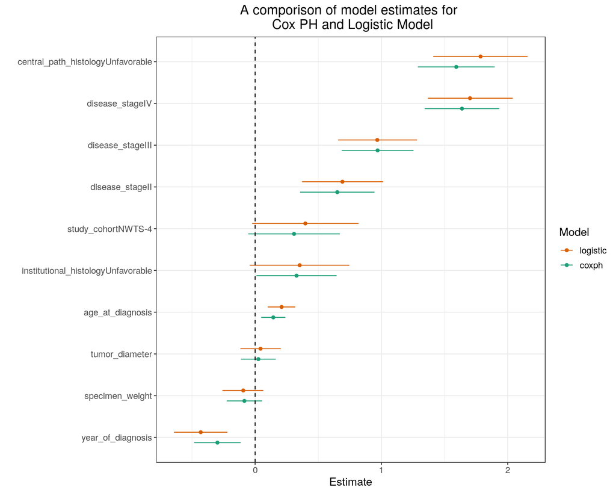

```r
# Extract coefs from the two models
extract_coefs_df <- (map(list(logistic = logistic_model, coxph = coxph_model), tidy, conf.int = TRUE)
    %>% bind_rows(.id = "model")
    %>% mutate(term = factor(term, levels = unique(term)))
    %>% filter(term != "(Intercept)")
    %>% mutate(term = reorder(term, estimate))
)

# Plot the model coefs
pos <- ggstance::position_dodgev(height=0.5)
compare_models_plot <- (ggplot(extract_coefs_df, aes(x = estimate, y = term, colour = model))
    + geom_point(position = pos)
    + ggstance::geom_linerangeh(aes(xmin = conf.low, xmax = conf.high), position = pos)
    + scale_colour_brewer(palette="Dark2"
        , guide = guide_legend(reverse = TRUE)
    )
    + geom_vline(xintercept=0,lty=2)
    + labs(x = "Estimate"
        , y = ""
        , colour = "Model"
        , title = "A comporison of model estimates for \n Cox PH and Logistic Model"
    )
    + theme(plot.title = element_text(hjust = 0.5)
        , text = element_text(size = 13)
    )
)
print(compare_models_plot)
```